# R Cheatsheet

Mark Ziemann

27/04/2020

Source: https://github.com/markziemann/SLE712_files/cheatsheet.Rmd

In this document we will be revising everything we covered in our Rstudio work in the form of a cut-down R markdown file.

## Week 1

### Arithmetic

We first covered arithmetic. Here are some examples.

```r
1+2
```

```
## [1] 3
```

```r
# comments can be placed after a hash
10000^2
```

```
## [1] 1e+08
```

```r
sqrt(64)
```

```
## [1] 8
```

```r
2^3
```

```
## [1] 8
```

```r
27^(1/3) # cube root
```

```
## [1] 3
```

```r
27^1/3 # parentheses matter!
```

```
## [1] 9
```

### Math on vectors

Math can also be done on vectors (a vector is a series of numbers). Let’s first save the vector as `a`.

```r
a <- c(1,10,100) # use the c() to create a vector
sum(a) # calculate the sum of a vector
```

```
## [1] 111
```

```r
mean(a) # calculate the mean of a vector
```

```
## [1] 37
```

```r
median(a) # calculate the median of a vector
```

```
## [1] 10
```

```r
max(a) # show the maximum value in a vector
```

```
## [1] 100
```

```r
min(a) # show the minimum value in a vector
```

```
## [1] 1
```

```r
range(a) # show maximum and minimum value
```

```
## [1]   1 100
```

```r
?range # use the ? to get help on a command
```

### Understanding object types

It is important to understand object types. It is a major source of errors in R. Currently `a` is a numerical vector. Here are some commands to determine an object’s type.

```r
str(a) # get data structure
```

```
##  num [1:3] 1 10 100
```

```r
typeof(a) # get data type (can be deceiving)
```

```
## [1] "double"
```

```r
class(a) # get data class
```

```
## [1] "numeric"
```

```r
b = "x1"
str(b)
```

```
##  chr "x1"
```

```r
typeof(b)
```

```
## [1] "character"
```

```r
class(b)
```

```
## [1] "character"
```

```r
c <- c("abc","def","ghi")
str(c)
```

```
##  chr [1:3] "abc" "def" "ghi"
```

```r
typeof(c)
```

```
## [1] "character"
```

```r
class(c)
```

```
## [1] "character"
```

### Square brackets

Subsetting vectors can be done with square brackets `[]`.

```r
a[2]  # get 2nd value
```

```
## [1] 10
```

```r
a[2:3] # get values in order
```

```
## [1]  10 100
```

```r
a[c(1,3)] # get values out of order
```

```
## [1]   1 100
```

```r
a[c(2,1)] # get values in reverse order
```

```
## [1] 10  1
```

### Reordering vectors

Reordering vectors can be done with square brackets `[]` as well.

```r
order(a) # rank the values from lowest to highest
```

```
## [1] 1 2 3
```

```r
order(-a) # rank values for highest to lowest
```

```
## [1] 3 2 1
```

```r
a[order(-a)] # reorder from highest to lowest
```

```
## [1] 100  10   1
```

```r
a <- a[order(-a)] # reorder and save as a
```

### Diagnosing object types/classes

We can find out a data type with the following commands.

```r
is.numeric(a) # check if numeric (value, vector or table)
```

```
## [1] TRUE
```

```r
is.character(b) # check if numeric (value, vector or table)
```

```
## [1] TRUE
```

```r
is.vector(c) # check if structure is vector or other data  type such as list or df
```

```
## [1] TRUE
```

```r
is.list(a) # check if structure is list
```

```
## [1] FALSE
```

```r
is.integer(a) # check if data is integers
```

```
## [1] FALSE
```

### Coercing types

We can coerce some data types to others.

```r
# for example, data can be imported as strings
d <- c("1","3","5","654")  # create a new vector of strings
str(d) # confirm the structure
```

```
##  chr [1:4] "1" "3" "5" "654"
```

```r
d <- as.numeric(d) # then convert to numeric
str(d) # confirm the structure
```

```
##  num [1:4] 1 3 5 654
```

```r
d <- as.integer(d) # coerce to integer
str(d) # confirm the structure
```

```
##  int [1:4] 1 3 5 654
```

```r
# we can give vector values names
names(d) <- c("s1","s2","s3","s4")
names(d) # show the names
```

```
## [1] "s1" "s2" "s3" "s4"
```

```r
str(d) # named vector looks a bit different in str
```

```
##  Named int [1:4] 1 3 5 654
##  - attr(*, "names")= chr [1:4] "s1" "s2" "s3" "s4"
```

```r
d <- as.list(d) # coerce data to a list
str(d) # confirm the structure
```

```
## List of 4
##  $ s1: int 1
##  $ s2: int 3
##  $ s3: int 5
##  $ s4: int 654
```

```r
d # have a look at the object in the console
```

```
## $s1
## [1] 1
##
## $s2
## [1] 3
##
## $s3
## [1] 5
##
## $s4
## [1] 654
```

## Pause and check your understanding

At this point you will be getting familiar with some of R’s data types. Can you describe clearly what the differences are between character strings, numerical values, vectors and lists? Do some reading online and take some notes if necessary.

## Two-dimensional data tables

Data frames and matrices are important data types in R.

### Converting vectors and dataframes

We can convert vectors to data frames and vice versa.

```r
b<-c(1.23,2.34,4.87,21.1) # create a new numerical vector
b<-as.data.frame(b) # coerce to df
str(b)
```

```
## 'data.frame':    4 obs. of  1 variable:
##  $ b: num  1.23 2.34 4.87 21.1
```

```r
b
```

```
##       b
## 1  1.23
## 2  2.34
## 3  4.87
## 4 21.10
```

```r
# set row names
rownames(b)<-c("sample1","sample2","sample3","sample4")
b
```

```
##             b
## sample1  1.23
## sample2  2.34
## sample3  4.87
## sample4 21.10
```

```r
colnames(b)="B" # set the column names
b
```

```
##             B
## sample1  1.23
## sample2  2.34
## sample3  4.87
## sample4 21.10
```

### The dollar-sign notation

The dollar sign $ allows us to address individual columns of a dataframe. If we specify a column name that doesn’t exist, we can create a new column with that name.

```r
b$B # extract a column of data from a df and show as a vector
```

```
## [1]  1.23  2.34  4.87 21.10
```

```r
b$D <- c(8.45,6.15,47.4,56.1) # create a new column of data
b
```

```
##             B     D
## sample1  1.23  8.45
## sample2  2.34  6.15
## sample3  4.87 47.40
## sample4 21.10 56.10
```

```r
b$F<-b$B+b$D # doing math with columns in dataframes!
b
```

```
##             B     D     F
## sample1  1.23  8.45  9.68
## sample2  2.34  6.15  8.49
## sample3  4.87 47.40 52.27
## sample4 21.10 56.10 77.20
```

It’s possible to do some mathematical operations on a column or whole df.

```r
b$D*100 # multiply a column by a number
```

```
## [1]  845  615 4740 5610
```

```r
b*100 # multiply a whole data frame by a number
```

```
##            B    D    F
## sample1  123  845  968
## sample2  234  615  849
## sample3  487 4740 5227
## sample4 2110 5610 7720
```

```r
b^2 # square each value of a data frame
```

```
##                B         D         F
## sample1   1.5129   71.4025   93.7024
## sample2   5.4756   37.8225   72.0801
## sample3  23.7169 2246.7600 2732.1529
## sample4 445.2100 3147.2100 5959.8400
```

```r
str(b) # str makes sense most of the time
```

```
## 'data.frame':    4 obs. of  3 variables:
##  $ B: num  1.23 2.34 4.87 21.1
##  $ D: num  8.45 6.15 47.4 56.1
##  $ F: num  9.68 8.49 52.27 77.2
```

```r
class(b) # makes sense as well
```

```
## [1] "data.frame"
```

```r
typeof(b) # sometimes deceptive
```

```
## [1] "list"
```

```r
str(as.matrix(b)) # see how matrix is stored differntly internally
```

```
##  num [1:4, 1:3] 1.23 2.34 4.87 21.1 8.45 6.15 47.4 56.1 9.68 8.49 ...
##  - attr(*, "dimnames")=List of 2
##   ..$ : chr [1:4] "sample1" "sample2" "sample3" "sample4"
##   ..$ : chr [1:3] "B" "D" "F"
```

```r
str(b)
```

```
## 'data.frame':    4 obs. of  3 variables:
##  $ B: num  1.23 2.34 4.87 21.1
##  $ D: num  8.45 6.15 47.4 56.1
##  $ F: num  9.68 8.49 52.27 77.2
```

### adding columns and rows to a dataframe

`cbind` adds new columns and `rbind` adds new rows.

```r
G<-c(78.03,54.8,98.1,0.2)
b<-cbind(b,as.data.frame(G)) # bind columns together
b
```

```
##             B     D     F     G
## sample1  1.23  8.45  9.68 78.03
## sample2  2.34  6.15  8.49 54.80
## sample3  4.87 47.40 52.27 98.10
## sample4 21.10 56.10 77.20  0.20
```

```r
sample5 <- c(12.1, 3.84, 549.1, 111.9)
b<-rbind(b,sample5,make.row.names =T) # bind rows together
b
```

```
##             B     D      F      G
## sample1  1.23  8.45   9.68  78.03
## sample2  2.34  6.15   8.49  54.80
## sample3  4.87 47.40  52.27  98.10
## sample4 21.10 56.10  77.20   0.20
## 5       12.10  3.84 549.10 111.90
```

```r
rownames(b)[5]<-"sample5" # change a single row name
b
```

```
##             B     D      F      G
## sample1  1.23  8.45   9.68  78.03
## sample2  2.34  6.15   8.49  54.80
## sample3  4.87 47.40  52.27  98.10
## sample4 21.10 56.10  77.20   0.20
## sample5 12.10  3.84 549.10 111.90
```

### other operations we can do on a dataframe or matrix

Here are some key commands that will help you analyze data and complete Assignment 3 as well.

```r
t(b) # transpose a df or matrix
```

```
##   sample1 sample2 sample3 sample4 sample5
## B    1.23    2.34    4.87    21.1   12.10
## D    8.45    6.15   47.40    56.1    3.84
## F    9.68    8.49   52.27    77.2  549.10
## G   78.03   54.80   98.10     0.2  111.90
```

```r
nrow(b) # get number of rows
```

```
## [1] 5
```

```r
ncol(b) # get number of columns
```

```
## [1] 4
```

```r
dim(b) # get number of rows and columns
```

```
## [1] 5 4
```

```r
rowMeans(b) # get means of all rows
```

```
##  sample1  sample2  sample3  sample4  sample5
##  24.3475  17.9450  50.6600  38.6500 169.2350
```

```r
colMeans(b) # get means of all columns
```

```
##       B       D       F       G
##   8.328  24.388 139.348  68.606
```

```r
rowSums(b) # get sum of all rows
```

```
## sample1 sample2 sample3 sample4 sample5
##   97.39   71.78  202.64  154.60  676.94
```

```r
colSums(b) # get sum of all columns
```

```
##      B      D      F      G
##  41.64 121.94 696.74 343.03
```

```r
summary(b) # get a nice summary of each column
```

```
##        B                D               F                G
##  Min.   : 1.230   Min.   : 3.84   Min.   :  8.49   Min.   :  0.20
##  1st Qu.: 2.340   1st Qu.: 6.15   1st Qu.:  9.68   1st Qu.: 54.80
##  Median : 4.870   Median : 8.45   Median : 52.27   Median : 78.03
##  Mean   : 8.328   Mean   :24.39   Mean   :139.35   Mean   : 68.61
##  3rd Qu.:12.100   3rd Qu.:47.40   3rd Qu.: 77.20   3rd Qu.: 98.10
##  Max.   :21.100   Max.   :56.10   Max.   :549.10   Max.   :111.90
```

```r
mean(b) # one does not simply calculate mean of a dataframe
```

```
## [1] NA
```

```r
mean(as.matrix(b)) # but it does work for a matrix
```

```
## [1] 60.1675
```

### Dot and line plots

Now let’s explore plots

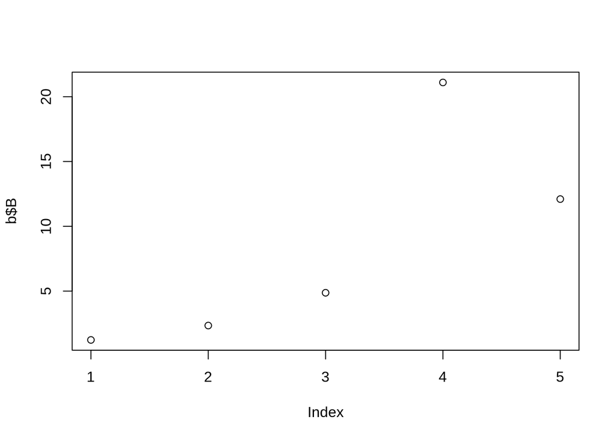

```r
plot(b$B) # dot plot a vector of values
```

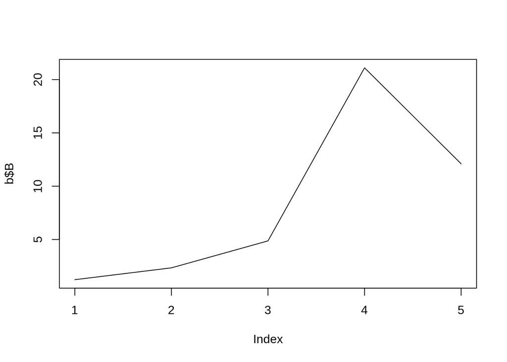

```r
plot(b$B, type = "l") # line plot a vector of values
```

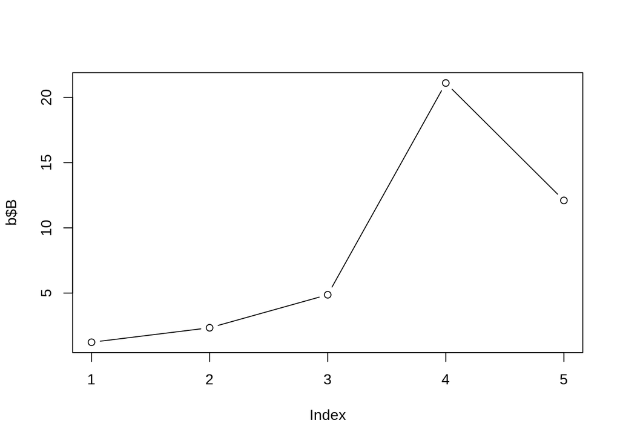

```r
plot(b$B, type = "b") # plot both lines and dots
```

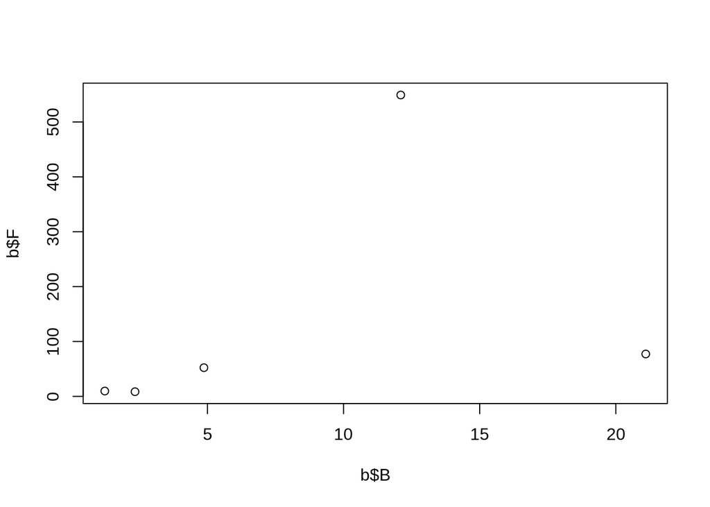

```r
plot(b$B, b$F) # scatter plot of two vectors
```

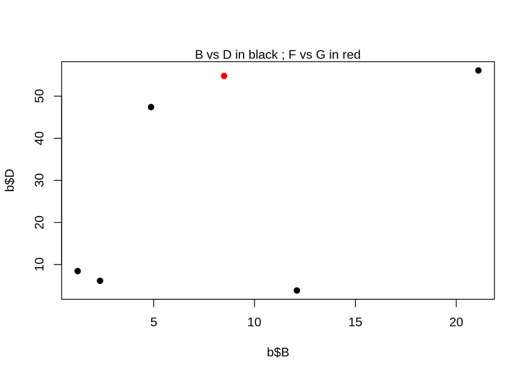

```r
plot(b$B, b$D, pch=19) # pch=19 gives nice circles
points(b$F,b$G,col="red",pch=19) # add red points. But make sure axis limits are wide enough!!
mtext("B vs D in black ; F vs G in red") # add a sub-heading
```

### Barplot and histograms

So that’s how to make a basic dot/line plot. Make sure you add axis labels with `xlab=` and `ylab=` options. Include the units of measurement and a main heading or subheading to better describe the data. Now let’s look at some other basic chart types.

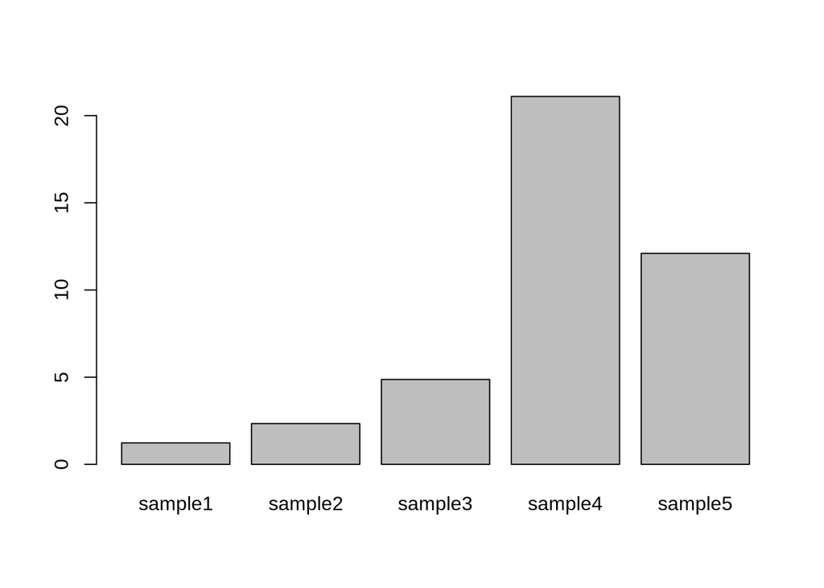

```r
barplot(b$B,names.arg=rownames(b)) # barplot works nicely if you supply the names.arg
```

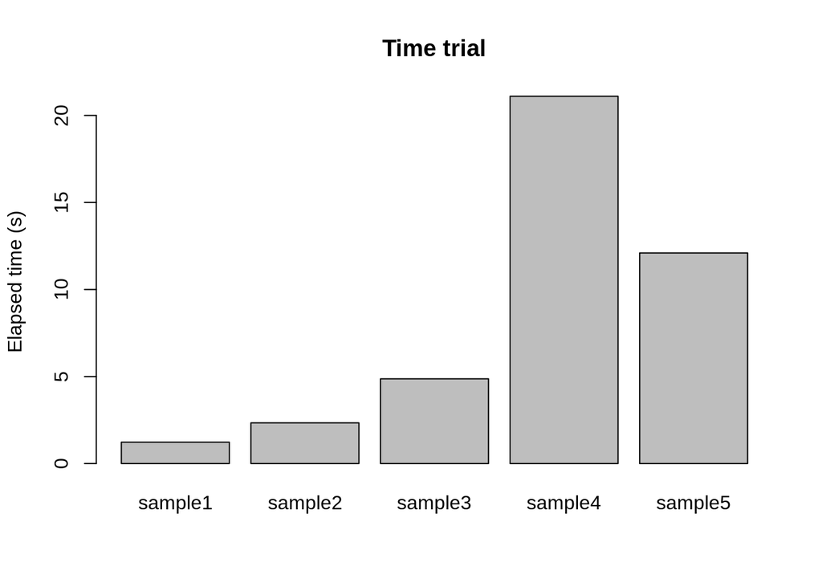

```r
# here is how you can add axis labels and main header
barplot(b$B,names.arg=rownames(b),ylab="Elapsed time (s)",
    main="Time trial")
```

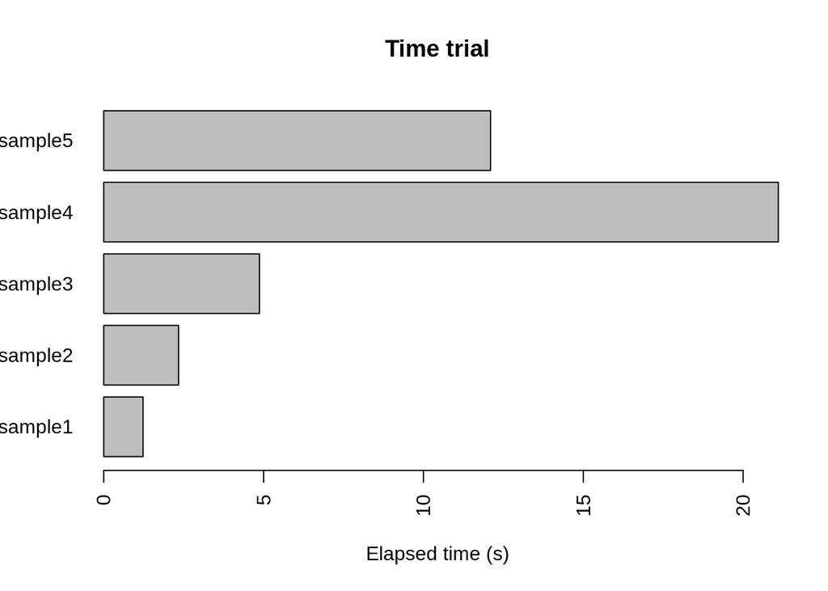

```r
# sometimes a horizontal chart looks better
barplot(b$B,names.arg=rownames(b),xlab="Elapsed time (s)",
    main="Time trial",horiz=T, las=2)
```

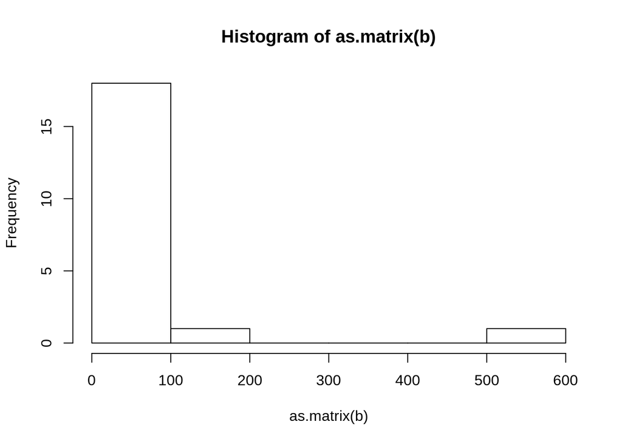

```r
# here's how to make a histogram
hist(as.matrix(b))
```

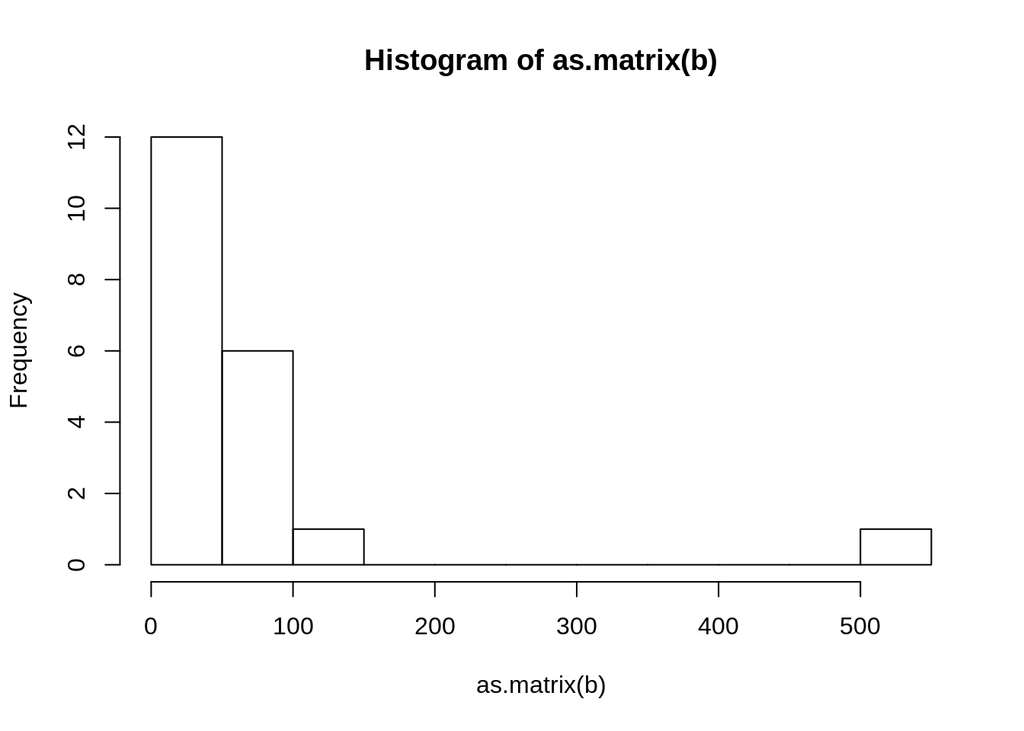

```r
# alter the number of histogram bins
hist(as.matrix(b),10)
```

### Histogram and boxplot with simulated data

The above histogram example uses a very small dataset. I think it would be better if we could use a bigger one. So lets create some new data with `rnorm`. This is a command to sample data from a distribution. Then we can get a nice looking histogram and introduce boxplot. Can you see the difference in the distributions in object `d` and `e`?

```r
d <- rnorm(n = 100,mean = 10,sd = 20) # sample 100 values from a distribution with mean=10 and SD=20
d
```

```
##   [1] -20.7519215  -4.9071587   3.1623552  37.5883821  22.0515959 -56.4738073
##   [7]  29.8483003  13.9080108   3.9012288 -14.9100357  34.1562985  18.7168925
##  [13]   0.0879152  -9.7814281  16.2511442  47.9552095   7.0074443  21.1510974
##  [19]  26.6342652  35.3082898   3.8804154  10.0462478  14.8919255  -9.8564980
##  [25]   5.7782254 -29.0980830  32.7087452   9.4895869 -30.4258071  28.2612515
##  [31]  37.4423670 -17.1491586  27.5777077  22.7283934   7.7499878   9.1103639
##  [37]  13.0651488  18.1036707  -7.0515323  16.7871205 -52.5327551   5.0681499
##  [43]   4.8376712  22.0538029  25.6522066  19.7132371  14.3160197  40.5024413
##  [49]  -1.9693970  -6.5673325  -5.7518890   6.8984187  33.1215755  -4.1087413
##  [55]  31.1238664 -22.0721936  -0.5242895  -5.2762898  27.7622534   5.4081623
##  [61]  31.7614696  -4.4756550 -37.0875333   6.9372043  -8.9970844  33.8242829
##  [67]  25.5548612   1.4608445  22.0831416 -10.3263395  15.7100976  18.5444432
##  [73]  -0.8208758  -5.6018401  -2.5339819  25.2602222 -22.9012537 -28.3806448
##  [79]  32.6709503  28.8004003   2.7542217  24.1943837   5.0446980  27.8280678
##  [85]  25.3965681   9.1189124  37.5648713  23.3068525 -31.7909710  23.0765410
##  [91]  19.4049227   4.8888323   1.4721806 -18.1257870   4.9902330  23.3896332
##  [97]  15.0525486  29.4778591  10.5762826  17.2151126
```

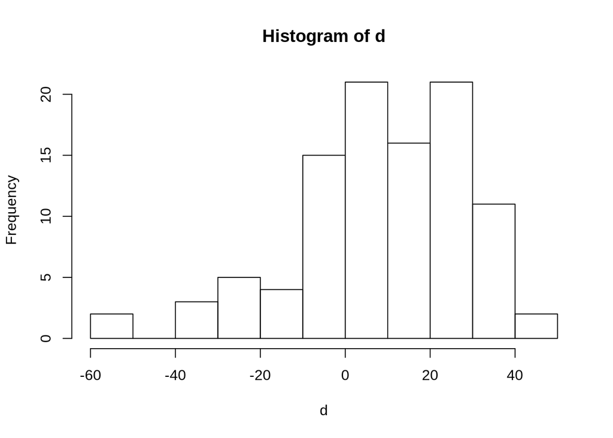

```r
e <- rnorm(n = 100,mean = 10,sd = 50)
hist(d)
```

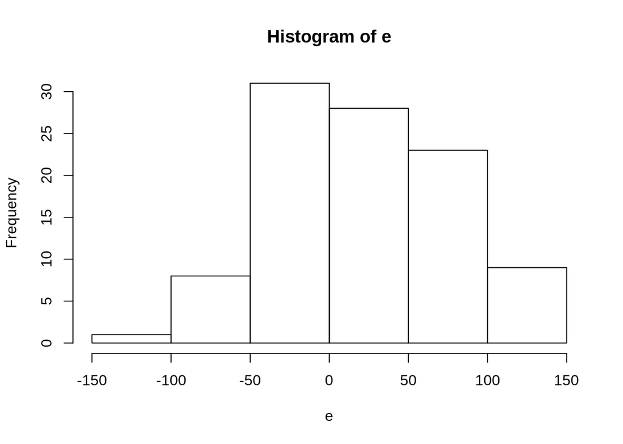

```r
hist(e)
```

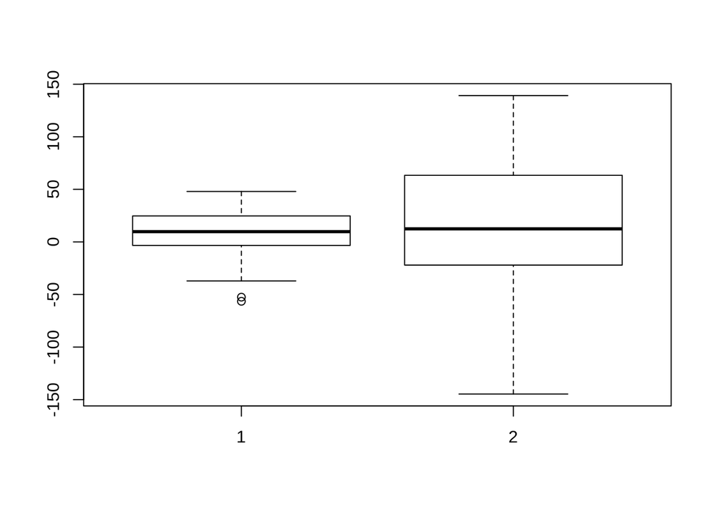

```r
boxplot(d,e)
```

# Export the PDF file

If you want to download the chart, you can use the export button in the lower right Rstudio window. A better alternative, especially for multiple charts is to create a multi-page PDF then download this file.

```r
pdf("myplots.pdf") # create a new, empty PDF
hist(d) # then add charts one by one
hist(e) # you can add lots and lots
boxplot(d,e) # and lots
dev.off() # when finished, you need to run dev.off() otherwise the PDF will appear as corrupted.
```

Check whether the file has been created in your current working directory and click on it to open in the web browser and find the button to save it.

## Week 2

### Factors

Let’s work with factors. Factors are an efficient way to store categorical data.

```r
g<-as.factor(c("M","M","F","F","M")) # in this command we are coercing strings to factors
str(g) # see how factors are represented in the object g
```

```
##  Factor w/ 2 levels "F","M": 2 2 1 1 2
```

```r
# We can specify the levels like this
f<-factor(c("early","late","ontime","early","late","ontime","early"),
          levels = c("early", "ontime", "late"))
f
```

```
## [1] early  late   ontime early  late   ontime early
## Levels: early ontime late
```

```r
str(f)
```

```
##  Factor w/ 3 levels "early","ontime",..: 1 3 2 1 3 2 1
```

```r
# Some factors are "ordinal" in that they have values that relate to each other
# such as high medium and low. we can specify this
f<-factor(c("early","late","ontime","early","late","ontime","early"),
          levels = c("early", "ontime", "late"), ordered =TRUE)
f
```

```
## [1] early  late   ontime early  late   ontime early
## Levels: early < ontime < late
```

```r
str(f)
```

```
##  Ord.factor w/ 3 levels "early"<"ontime"<..: 1 3 2 1 3 2 1
```

```r
as.character(f) # coerse factor to character
```

```
## [1] "early"  "late"   "ontime" "early"  "late"   "ontime" "early"
```

```r
as.numeric(f) # coerce factor to numeric
```

```
## [1] 1 3 2 1 3 2 1
```

### Subsetting data frames part 1

We can subset a column from a data frame with the `df$col` notation. With the `[rows,cols]` square brackets we can select both rows and columns.

```r
data(mtcars) # make sure that mtcars is available
mtcars # show mtcars in the console
```

```
##                      mpg cyl  disp  hp drat    wt  qsec vs am gear carb
## Mazda RX4           21.0   6 160.0 110 3.90 2.620 16.46  0  1    4    4
## Mazda RX4 Wag       21.0   6 160.0 110 3.90 2.875 17.02  0  1    4    4
## Datsun 710          22.8   4 108.0  93 3.85 2.320 18.61  1  1    4    1
## Hornet 4 Drive      21.4   6 258.0 110 3.08 3.215 19.44  1  0    3    1
## Hornet Sportabout   18.7   8 360.0 175 3.15 3.440 17.02  0  0    3    2
## Valiant             18.1   6 225.0 105 2.76 3.460 20.22  1  0    3    1
## Duster 360          14.3   8 360.0 245 3.21 3.570 15.84  0  0    3    4
## Merc 240D           24.4   4 146.7  62 3.69 3.190 20.00  1  0    4    2
## Merc 230            22.8   4 140.8  95 3.92 3.150 22.90  1  0    4    2
## Merc 280            19.2   6 167.6 123 3.92 3.440 18.30  1  0    4    4
## Merc 280C           17.8   6 167.6 123 3.92 3.440 18.90  1  0    4    4
## Merc 450SE          16.4   8 275.8 180 3.07 4.070 17.40  0  0    3    3
## Merc 450SL          17.3   8 275.8 180 3.07 3.730 17.60  0  0    3    3
## Merc 450SLC         15.2   8 275.8 180 3.07 3.780 18.00  0  0    3    3
## Cadillac Fleetwood  10.4   8 472.0 205 2.93 5.250 17.98  0  0    3    4
## Lincoln Continental 10.4   8 460.0 215 3.00 5.424 17.82  0  0    3    4
## Chrysler Imperial   14.7   8 440.0 230 3.23 5.345 17.42  0  0    3    4
## Fiat 128            32.4   4  78.7  66 4.08 2.200 19.47  1  1    4    1
## Honda Civic         30.4   4  75.7  52 4.93 1.615 18.52  1  1    4    2
## Toyota Corolla      33.9   4  71.1  65 4.22 1.835 19.90  1  1    4    1
## Toyota Corona       21.5   4 120.1  97 3.70 2.465 20.01  1  0    3    1
## Dodge Challenger    15.5   8 318.0 150 2.76 3.520 16.87  0  0    3    2
## AMC Javelin         15.2   8 304.0 150 3.15 3.435 17.30  0  0    3    2
## Camaro Z28          13.3   8 350.0 245 3.73 3.840 15.41  0  0    3    4
## Pontiac Firebird    19.2   8 400.0 175 3.08 3.845 17.05  0  0    3    2
## Fiat X1-9           27.3   4  79.0  66 4.08 1.935 18.90  1  1    4    1
## Porsche 914-2       26.0   4 120.3  91 4.43 2.140 16.70  0  1    5    2
## Lotus Europa        30.4   4  95.1 113 3.77 1.513 16.90  1  1    5    2
## Ford Pantera L      15.8   8 351.0 264 4.22 3.170 14.50  0  1    5    4
## Ferrari Dino        19.7   6 145.0 175 3.62 2.770 15.50  0  1    5    6
## Maserati Bora       15.0   8 301.0 335 3.54 3.570 14.60  0  1    5    8
## Volvo 142E          21.4   4 121.0 109 4.11 2.780 18.60  1  1    4    2
```

```r
mtcars$mpg # extract one column with $ notation
```

```
##  [1] 21.0 21.0 22.8 21.4 18.7 18.1 14.3 24.4 22.8 19.2 17.8 16.4 17.3 15.2 10.4
## [16] 10.4 14.7 32.4 30.4 33.9 21.5 15.5 15.2 13.3 19.2 27.3 26.0 30.4 15.8 19.7
## [31] 15.0 21.4
```

```r
mtcars[,"mpg"] # it can also be done with [] notation by specifying the col name
```

```
##  [1] 21.0 21.0 22.8 21.4 18.7 18.1 14.3 24.4 22.8 19.2 17.8 16.4 17.3 15.2 10.4
## [16] 10.4 14.7 32.4 30.4 33.9 21.5 15.5 15.2 13.3 19.2 27.3 26.0 30.4 15.8 19.7
## [31] 15.0 21.4
```

```r
mtcars[,1] # or specifying the location. Here we extract  the 1st col
```

```
##  [1] 21.0 21.0 22.8 21.4 18.7 18.1 14.3 24.4 22.8 19.2 17.8 16.4 17.3 15.2 10.4
## [16] 10.4 14.7 32.4 30.4 33.9 21.5 15.5 15.2 13.3 19.2 27.3 26.0 30.4 15.8 19.7
## [31] 15.0 21.4
```

```r
mtcars[,1:3] # range of columns
```

```
##                      mpg cyl  disp
## Mazda RX4           21.0   6 160.0
## Mazda RX4 Wag       21.0   6 160.0
## Datsun 710          22.8   4 108.0
## Hornet 4 Drive      21.4   6 258.0
## Hornet Sportabout   18.7   8 360.0
## Valiant             18.1   6 225.0
## Duster 360          14.3   8 360.0
## Merc 240D           24.4   4 146.7
## Merc 230            22.8   4 140.8
## Merc 280            19.2   6 167.6
## Merc 280C           17.8   6 167.6
## Merc 450SE          16.4   8 275.8
## Merc 450SL          17.3   8 275.8
## Merc 450SLC         15.2   8 275.8
## Cadillac Fleetwood  10.4   8 472.0
## Lincoln Continental 10.4   8 460.0
## Chrysler Imperial   14.7   8 440.0
## Fiat 128            32.4   4  78.7
## Honda Civic         30.4   4  75.7
## Toyota Corolla      33.9   4  71.1
## Toyota Corona       21.5   4 120.1
## Dodge Challenger    15.5   8 318.0
## AMC Javelin         15.2   8 304.0
## Camaro Z28          13.3   8 350.0
## Pontiac Firebird    19.2   8 400.0
## Fiat X1-9           27.3   4  79.0
## Porsche 914-2       26.0   4 120.3
## Lotus Europa        30.4   4  95.1
## Ford Pantera L      15.8   8 351.0
## Ferrari Dino        19.7   6 145.0
## Maserati Bora       15.0   8 301.0
## Volvo 142E          21.4   4 121.0
```

```r
mtcars[,c(3,1,8)] # columns in different order
```

```
##                      disp  mpg vs
## Mazda RX4           160.0 21.0  0
## Mazda RX4 Wag       160.0 21.0  0
## Datsun 710          108.0 22.8  1
## Hornet 4 Drive      258.0 21.4  1
## Hornet Sportabout   360.0 18.7  0
## Valiant             225.0 18.1  1
## Duster 360          360.0 14.3  0
## Merc 240D           146.7 24.4  1
## Merc 230            140.8 22.8  1
## Merc 280            167.6 19.2  1
## Merc 280C           167.6 17.8  1
## Merc 450SE          275.8 16.4  0
## Merc 450SL          275.8 17.3  0
## Merc 450SLC         275.8 15.2  0
## Cadillac Fleetwood  472.0 10.4  0
## Lincoln Continental 460.0 10.4  0
## Chrysler Imperial   440.0 14.7  0
## Fiat 128             78.7 32.4  1
## Honda Civic          75.7 30.4  1
## Toyota Corolla       71.1 33.9  1
## Toyota Corona       120.1 21.5  1
## Dodge Challenger    318.0 15.5  0
## AMC Javelin         304.0 15.2  0
## Camaro Z28          350.0 13.3  0
## Pontiac Firebird    400.0 19.2  0
## Fiat X1-9            79.0 27.3  1
## Porsche 914-2       120.3 26.0  0
## Lotus Europa         95.1 30.4  1
## Ford Pantera L      351.0 15.8  0
## Ferrari Dino        145.0 19.7  0
## Maserati Bora       301.0 15.0  0
## Volvo 142E          121.0 21.4  1
```

```r
mtcars[1:4,] # rows as well
```

```
##                 mpg cyl disp  hp drat    wt  qsec vs am gear carb
## Mazda RX4      21.0   6  160 110 3.90 2.620 16.46  0  1    4    4
## Mazda RX4 Wag  21.0   6  160 110 3.90 2.875 17.02  0  1    4    4
## Datsun 710     22.8   4  108  93 3.85 2.320 18.61  1  1    4    1
## Hornet 4 Drive 21.4   6  258 110 3.08 3.215 19.44  1  0    3    1
```

```r
mtcars[1:4,1:6] # rows and columns
```

```
##                 mpg cyl disp  hp drat    wt
## Mazda RX4      21.0   6  160 110 3.90 2.620
## Mazda RX4 Wag  21.0   6  160 110 3.90 2.875
## Datsun 710     22.8   4  108  93 3.85 2.320
## Hornet 4 Drive 21.4   6  258 110 3.08 3.215
```

### Subsetting data frames part 2

The above is useful, but most subsetting jobs are based on the values inside the data frame.

```r
mtcars$mpg>20 # ask the question which mpg values are >20
```

```
##  [1]  TRUE  TRUE  TRUE  TRUE FALSE FALSE FALSE  TRUE  TRUE FALSE FALSE FALSE
## [13] FALSE FALSE FALSE FALSE FALSE  TRUE  TRUE  TRUE  TRUE FALSE FALSE FALSE
## [25] FALSE  TRUE  TRUE  TRUE FALSE FALSE FALSE  TRUE
```

```r
mtcars[,"mpg"]>20 # same thing
```

```
##  [1]  TRUE  TRUE  TRUE  TRUE FALSE FALSE FALSE  TRUE  TRUE FALSE FALSE FALSE
## [13] FALSE FALSE FALSE FALSE FALSE  TRUE  TRUE  TRUE  TRUE FALSE FALSE FALSE
## [25] FALSE  TRUE  TRUE  TRUE FALSE FALSE FALSE  TRUE
```

```r
mtcars[,1]>20 # same thing again
```

```
##  [1]  TRUE  TRUE  TRUE  TRUE FALSE FALSE FALSE  TRUE  TRUE FALSE FALSE FALSE
## [13] FALSE FALSE FALSE FALSE FALSE  TRUE  TRUE  TRUE  TRUE FALSE FALSE FALSE
## [25] FALSE  TRUE  TRUE  TRUE FALSE FALSE FALSE  TRUE
```

```r
which(mtcars[,1]>20) # Which command extracts all the TRUE values
```

```
##  [1]  1  2  3  4  8  9 18 19 20 21 26 27 28 32
```

```r
mtcars[which(mtcars[,1]>20),] # use which inside the square brackets to subset cars with mpg>20
```

```
##                 mpg cyl  disp  hp drat    wt  qsec vs am gear carb
## Mazda RX4      21.0   6 160.0 110 3.90 2.620 16.46  0  1    4    4
## Mazda RX4 Wag  21.0   6 160.0 110 3.90 2.875 17.02  0  1    4    4
## Datsun 710     22.8   4 108.0  93 3.85 2.320 18.61  1  1    4    1
## Hornet 4 Drive 21.4   6 258.0 110 3.08 3.215 19.44  1  0    3    1
## Merc 240D      24.4   4 146.7  62 3.69 3.190 20.00  1  0    4    2
## Merc 230       22.8   4 140.8  95 3.92 3.150 22.90  1  0    4    2
## Fiat 128       32.4   4  78.7  66 4.08 2.200 19.47  1  1    4    1
## Honda Civic    30.4   4  75.7  52 4.93 1.615 18.52  1  1    4    2
## Toyota Corolla 33.9   4  71.1  65 4.22 1.835 19.90  1  1    4    1
## Toyota Corona  21.5   4 120.1  97 3.70 2.465 20.01  1  0    3    1
## Fiat X1-9      27.3   4  79.0  66 4.08 1.935 18.90  1  1    4    1
## Porsche 914-2  26.0   4 120.3  91 4.43 2.140 16.70  0  1    5    2
## Lotus Europa   30.4   4  95.1 113 3.77 1.513 16.90  1  1    5    2
## Volvo 142E     21.4   4 121.0 109 4.11 2.780 18.60  1  1    4    2
```

```r
subset(mtcars, mpg>20) # a simpler way to do it.
```

```
##                 mpg cyl  disp  hp drat    wt  qsec vs am gear carb
## Mazda RX4      21.0   6 160.0 110 3.90 2.620 16.46  0  1    4    4
## Mazda RX4 Wag  21.0   6 160.0 110 3.90 2.875 17.02  0  1    4    4
## Datsun 710     22.8   4 108.0  93 3.85 2.320 18.61  1  1    4    1
## Hornet 4 Drive 21.4   6 258.0 110 3.08 3.215 19.44  1  0    3    1
## Merc 240D      24.4   4 146.7  62 3.69 3.190 20.00  1  0    4    2
## Merc 230       22.8   4 140.8  95 3.92 3.150 22.90  1  0    4    2
## Fiat 128       32.4   4  78.7  66 4.08 2.200 19.47  1  1    4    1
## Honda Civic    30.4   4  75.7  52 4.93 1.615 18.52  1  1    4    2
## Toyota Corolla 33.9   4  71.1  65 4.22 1.835 19.90  1  1    4    1
## Toyota Corona  21.5   4 120.1  97 3.70 2.465 20.01  1  0    3    1
## Fiat X1-9      27.3   4  79.0  66 4.08 1.935 18.90  1  1    4    1
## Porsche 914-2  26.0   4 120.3  91 4.43 2.140 16.70  0  1    5    2
## Lotus Europa   30.4   4  95.1 113 3.77 1.513 16.90  1  1    5    2
## Volvo 142E     21.4   4 121.0 109 4.11 2.780 18.60  1  1    4    2
```

```r
subset(mtcars, mpg>20 & cyl>5) # multiple conditions with AND
```

```
##                 mpg cyl disp  hp drat    wt  qsec vs am gear carb
## Mazda RX4      21.0   6  160 110 3.90 2.620 16.46  0  1    4    4
## Mazda RX4 Wag  21.0   6  160 110 3.90 2.875 17.02  0  1    4    4
## Hornet 4 Drive 21.4   6  258 110 3.08 3.215 19.44  1  0    3    1
```

```r
subset(mtcars, mpg>20 | cyl>5) # multiple conditions with OR
```

```
##                      mpg cyl  disp  hp drat    wt  qsec vs am gear carb
## Mazda RX4           21.0   6 160.0 110 3.90 2.620 16.46  0  1    4    4
## Mazda RX4 Wag       21.0   6 160.0 110 3.90 2.875 17.02  0  1    4    4
## Datsun 710          22.8   4 108.0  93 3.85 2.320 18.61  1  1    4    1
## Hornet 4 Drive      21.4   6 258.0 110 3.08 3.215 19.44  1  0    3    1
## Hornet Sportabout   18.7   8 360.0 175 3.15 3.440 17.02  0  0    3    2
## Valiant             18.1   6 225.0 105 2.76 3.460 20.22  1  0    3    1
## Duster 360          14.3   8 360.0 245 3.21 3.570 15.84  0  0    3    4
## Merc 240D           24.4   4 146.7  62 3.69 3.190 20.00  1  0    4    2
## Merc 230            22.8   4 140.8  95 3.92 3.150 22.90  1  0    4    2
## Merc 280            19.2   6 167.6 123 3.92 3.440 18.30  1  0    4    4
## Merc 280C           17.8   6 167.6 123 3.92 3.440 18.90  1  0    4    4
## Merc 450SE          16.4   8 275.8 180 3.07 4.070 17.40  0  0    3    3
## Merc 450SL          17.3   8 275.8 180 3.07 3.730 17.60  0  0    3    3
## Merc 450SLC         15.2   8 275.8 180 3.07 3.780 18.00  0  0    3    3
## Cadillac Fleetwood  10.4   8 472.0 205 2.93 5.250 17.98  0  0    3    4
## Lincoln Continental 10.4   8 460.0 215 3.00 5.424 17.82  0  0    3    4
## Chrysler Imperial   14.7   8 440.0 230 3.23 5.345 17.42  0  0    3    4
## Fiat 128            32.4   4  78.7  66 4.08 2.200 19.47  1  1    4    1
## Honda Civic         30.4   4  75.7  52 4.93 1.615 18.52  1  1    4    2
## Toyota Corolla      33.9   4  71.1  65 4.22 1.835 19.90  1  1    4    1
## Toyota Corona       21.5   4 120.1  97 3.70 2.465 20.01  1  0    3    1
## Dodge Challenger    15.5   8 318.0 150 2.76 3.520 16.87  0  0    3    2
## AMC Javelin         15.2   8 304.0 150 3.15 3.435 17.30  0  0    3    2
## Camaro Z28          13.3   8 350.0 245 3.73 3.840 15.41  0  0    3    4
## Pontiac Firebird    19.2   8 400.0 175 3.08 3.845 17.05  0  0    3    2
## Fiat X1-9           27.3   4  79.0  66 4.08 1.935 18.90  1  1    4    1
## Porsche 914-2       26.0   4 120.3  91 4.43 2.140 16.70  0  1    5    2
## Lotus Europa        30.4   4  95.1 113 3.77 1.513 16.90  1  1    5    2
## Ford Pantera L      15.8   8 351.0 264 4.22 3.170 14.50  0  1    5    4
## Ferrari Dino        19.7   6 145.0 175 3.62 2.770 15.50  0  1    5    6
## Maserati Bora       15.0   8 301.0 335 3.54 3.570 14.60  0  1    5    8
## Volvo 142E          21.4   4 121.0 109 4.11 2.780 18.60  1  1    4    2
```

While `subset` command is easier, you still need to know the `[]` way of doing it because that is more versatile and used in the next section.

### Reordering a data frame

It is a very common procedure to reorder a dataframe based on the values. Note that it is a 2 step process. 1st to rank the values and 2nd to extract rows/cols in that order. This is likely to be on the exam.

```r
order(mtcars$mpg) # rank the values in a column (vector)
```

```
##  [1] 15 16 24  7 17 31 14 23 22 29 12 13 11  6  5 10 25 30  1  2  4 32 21  3  9
## [26]  8 27 26 19 28 18 20
```

```r
mtcars[order(mtcars$mpg),] # stick the order command in the square brackets to extract the rows in order.
```

```
##                      mpg cyl  disp  hp drat    wt  qsec vs am gear carb
## Cadillac Fleetwood  10.4   8 472.0 205 2.93 5.250 17.98  0  0    3    4
## Lincoln Continental 10.4   8 460.0 215 3.00 5.424 17.82  0  0    3    4
## Camaro Z28          13.3   8 350.0 245 3.73 3.840 15.41  0  0    3    4
## Duster 360          14.3   8 360.0 245 3.21 3.570 15.84  0  0    3    4
## Chrysler Imperial   14.7   8 440.0 230 3.23 5.345 17.42  0  0    3    4
## Maserati Bora       15.0   8 301.0 335 3.54 3.570 14.60  0  1    5    8
## Merc 450SLC         15.2   8 275.8 180 3.07 3.780 18.00  0  0    3    3
## AMC Javelin         15.2   8 304.0 150 3.15 3.435 17.30  0  0    3    2
## Dodge Challenger    15.5   8 318.0 150 2.76 3.520 16.87  0  0    3    2
## Ford Pantera L      15.8   8 351.0 264 4.22 3.170 14.50  0  1    5    4
## Merc 450SE          16.4   8 275.8 180 3.07 4.070 17.40  0  0    3    3
## Merc 450SL          17.3   8 275.8 180 3.07 3.730 17.60  0  0    3    3
## Merc 280C           17.8   6 167.6 123 3.92 3.440 18.90  1  0    4    4
## Valiant             18.1   6 225.0 105 2.76 3.460 20.22  1  0    3    1
## Hornet Sportabout   18.7   8 360.0 175 3.15 3.440 17.02  0  0    3    2
## Merc 280            19.2   6 167.6 123 3.92 3.440 18.30  1  0    4    4
## Pontiac Firebird    19.2   8 400.0 175 3.08 3.845 17.05  0  0    3    2
## Ferrari Dino        19.7   6 145.0 175 3.62 2.770 15.50  0  1    5    6
## Mazda RX4           21.0   6 160.0 110 3.90 2.620 16.46  0  1    4    4
## Mazda RX4 Wag       21.0   6 160.0 110 3.90 2.875 17.02  0  1    4    4
## Hornet 4 Drive      21.4   6 258.0 110 3.08 3.215 19.44  1  0    3    1
## Volvo 142E          21.4   4 121.0 109 4.11 2.780 18.60  1  1    4    2
## Toyota Corona       21.5   4 120.1  97 3.70 2.465 20.01  1  0    3    1
## Datsun 710          22.8   4 108.0  93 3.85 2.320 18.61  1  1    4    1
## Merc 230            22.8   4 140.8  95 3.92 3.150 22.90  1  0    4    2
## Merc 240D           24.4   4 146.7  62 3.69 3.190 20.00  1  0    4    2
## Porsche 914-2       26.0   4 120.3  91 4.43 2.140 16.70  0  1    5    2
## Fiat X1-9           27.3   4  79.0  66 4.08 1.935 18.90  1  1    4    1
## Honda Civic         30.4   4  75.7  52 4.93 1.615 18.52  1  1    4    2
## Lotus Europa        30.4   4  95.1 113 3.77 1.513 16.90  1  1    5    2
## Fiat 128            32.4   4  78.7  66 4.08 2.200 19.47  1  1    4    1
## Toyota Corolla      33.9   4  71.1  65 4.22 1.835 19.90  1  1    4    1
```

```r
mtcars[order(-mtcars$mpg),] # reverse the order
```

```
##                      mpg cyl  disp  hp drat    wt  qsec vs am gear carb
## Toyota Corolla      33.9   4  71.1  65 4.22 1.835 19.90  1  1    4    1
## Fiat 128            32.4   4  78.7  66 4.08 2.200 19.47  1  1    4    1
## Honda Civic         30.4   4  75.7  52 4.93 1.615 18.52  1  1    4    2
## Lotus Europa        30.4   4  95.1 113 3.77 1.513 16.90  1  1    5    2
## Fiat X1-9           27.3   4  79.0  66 4.08 1.935 18.90  1  1    4    1
## Porsche 914-2       26.0   4 120.3  91 4.43 2.140 16.70  0  1    5    2
## Merc 240D           24.4   4 146.7  62 3.69 3.190 20.00  1  0    4    2
## Datsun 710          22.8   4 108.0  93 3.85 2.320 18.61  1  1    4    1
## Merc 230            22.8   4 140.8  95 3.92 3.150 22.90  1  0    4    2
## Toyota Corona       21.5   4 120.1  97 3.70 2.465 20.01  1  0    3    1
## Hornet 4 Drive      21.4   6 258.0 110 3.08 3.215 19.44  1  0    3    1
## Volvo 142E          21.4   4 121.0 109 4.11 2.780 18.60  1  1    4    2
## Mazda RX4           21.0   6 160.0 110 3.90 2.620 16.46  0  1    4    4
## Mazda RX4 Wag       21.0   6 160.0 110 3.90 2.875 17.02  0  1    4    4
## Ferrari Dino        19.7   6 145.0 175 3.62 2.770 15.50  0  1    5    6
## Merc 280            19.2   6 167.6 123 3.92 3.440 18.30  1  0    4    4
## Pontiac Firebird    19.2   8 400.0 175 3.08 3.845 17.05  0  0    3    2
## Hornet Sportabout   18.7   8 360.0 175 3.15 3.440 17.02  0  0    3    2
## Valiant             18.1   6 225.0 105 2.76 3.460 20.22  1  0    3    1
## Merc 280C           17.8   6 167.6 123 3.92 3.440 18.90  1  0    4    4
## Merc 450SL          17.3   8 275.8 180 3.07 3.730 17.60  0  0    3    3
## Merc 450SE          16.4   8 275.8 180 3.07 4.070 17.40  0  0    3    3
## Ford Pantera L      15.8   8 351.0 264 4.22 3.170 14.50  0  1    5    4
## Dodge Challenger    15.5   8 318.0 150 2.76 3.520 16.87  0  0    3    2
## Merc 450SLC         15.2   8 275.8 180 3.07 3.780 18.00  0  0    3    3
## AMC Javelin         15.2   8 304.0 150 3.15 3.435 17.30  0  0    3    2
## Maserati Bora       15.0   8 301.0 335 3.54 3.570 14.60  0  1    5    8
## Chrysler Imperial   14.7   8 440.0 230 3.23 5.345 17.42  0  0    3    4
## Duster 360          14.3   8 360.0 245 3.21 3.570 15.84  0  0    3    4
## Camaro Z28          13.3   8 350.0 245 3.73 3.840 15.41  0  0    3    4
## Cadillac Fleetwood  10.4   8 472.0 205 2.93 5.250 17.98  0  0    3    4
## Lincoln Continental 10.4   8 460.0 215 3.00 5.424 17.82  0  0    3    4
```

```r
mtcars[order(rownames(mtcars)),] # reordering based on the alphabetical order of the rownames
```

```
##                      mpg cyl  disp  hp drat    wt  qsec vs am gear carb
## AMC Javelin         15.2   8 304.0 150 3.15 3.435 17.30  0  0    3    2
## Cadillac Fleetwood  10.4   8 472.0 205 2.93 5.250 17.98  0  0    3    4
## Camaro Z28          13.3   8 350.0 245 3.73 3.840 15.41  0  0    3    4
## Chrysler Imperial   14.7   8 440.0 230 3.23 5.345 17.42  0  0    3    4
## Datsun 710          22.8   4 108.0  93 3.85 2.320 18.61  1  1    4    1
## Dodge Challenger    15.5   8 318.0 150 2.76 3.520 16.87  0  0    3    2
## Duster 360          14.3   8 360.0 245 3.21 3.570 15.84  0  0    3    4
## Ferrari Dino        19.7   6 145.0 175 3.62 2.770 15.50  0  1    5    6
## Fiat 128            32.4   4  78.7  66 4.08 2.200 19.47  1  1    4    1
## Fiat X1-9           27.3   4  79.0  66 4.08 1.935 18.90  1  1    4    1
## Ford Pantera L      15.8   8 351.0 264 4.22 3.170 14.50  0  1    5    4
## Honda Civic         30.4   4  75.7  52 4.93 1.615 18.52  1  1    4    2
## Hornet 4 Drive      21.4   6 258.0 110 3.08 3.215 19.44  1  0    3    1
## Hornet Sportabout   18.7   8 360.0 175 3.15 3.440 17.02  0  0    3    2
## Lincoln Continental 10.4   8 460.0 215 3.00 5.424 17.82  0  0    3    4
## Lotus Europa        30.4   4  95.1 113 3.77 1.513 16.90  1  1    5    2
## Maserati Bora       15.0   8 301.0 335 3.54 3.570 14.60  0  1    5    8
## Mazda RX4           21.0   6 160.0 110 3.90 2.620 16.46  0  1    4    4
## Mazda RX4 Wag       21.0   6 160.0 110 3.90 2.875 17.02  0  1    4    4
## Merc 230            22.8   4 140.8  95 3.92 3.150 22.90  1  0    4    2
## Merc 240D           24.4   4 146.7  62 3.69 3.190 20.00  1  0    4    2
## Merc 280            19.2   6 167.6 123 3.92 3.440 18.30  1  0    4    4
## Merc 280C           17.8   6 167.6 123 3.92 3.440 18.90  1  0    4    4
## Merc 450SE          16.4   8 275.8 180 3.07 4.070 17.40  0  0    3    3
## Merc 450SL          17.3   8 275.8 180 3.07 3.730 17.60  0  0    3    3
## Merc 450SLC         15.2   8 275.8 180 3.07 3.780 18.00  0  0    3    3
## Pontiac Firebird    19.2   8 400.0 175 3.08 3.845 17.05  0  0    3    2
## Porsche 914-2       26.0   4 120.3  91 4.43 2.140 16.70  0  1    5    2
## Toyota Corolla      33.9   4  71.1  65 4.22 1.835 19.90  1  1    4    1
## Toyota Corona       21.5   4 120.1  97 3.70 2.465 20.01  1  0    3    1
## Valiant             18.1   6 225.0 105 2.76 3.460 20.22  1  0    3    1
## Volvo 142E          21.4   4 121.0 109 4.11 2.780 18.60  1  1    4    2
```

### Linear regression example

Linear regression is one of those fundamental, essential skills in R. Let’s take a look at the correlation between number of cylinders and mpg (or 1/mpg).

```r
mtcars[,1:2] # extract 1st and 2nd column
```

```
##                      mpg cyl
## Mazda RX4           21.0   6
## Mazda RX4 Wag       21.0   6
## Datsun 710          22.8   4
## Hornet 4 Drive      21.4   6
## Hornet Sportabout   18.7   8
## Valiant             18.1   6
## Duster 360          14.3   8
## Merc 240D           24.4   4
## Merc 230            22.8   4
## Merc 280            19.2   6
## Merc 280C           17.8   6
## Merc 450SE          16.4   8
## Merc 450SL          17.3   8
## Merc 450SLC         15.2   8
## Cadillac Fleetwood  10.4   8
## Lincoln Continental 10.4   8
## Chrysler Imperial   14.7   8
## Fiat 128            32.4   4
## Honda Civic         30.4   4
## Toyota Corolla      33.9   4
## Toyota Corona       21.5   4
## Dodge Challenger    15.5   8
## AMC Javelin         15.2   8
## Camaro Z28          13.3   8
## Pontiac Firebird    19.2   8
## Fiat X1-9           27.3   4
## Porsche 914-2       26.0   4
## Lotus Europa        30.4   4
## Ford Pantera L      15.8   8
## Ferrari Dino        19.7   6
## Maserati Bora       15.0   8
## Volvo 142E          21.4   4
```

```r
cor(mtcars[,1:2]) # simple correlation
```

```
##           mpg       cyl
## mpg  1.000000 -0.852162
## cyl -0.852162  1.000000
```

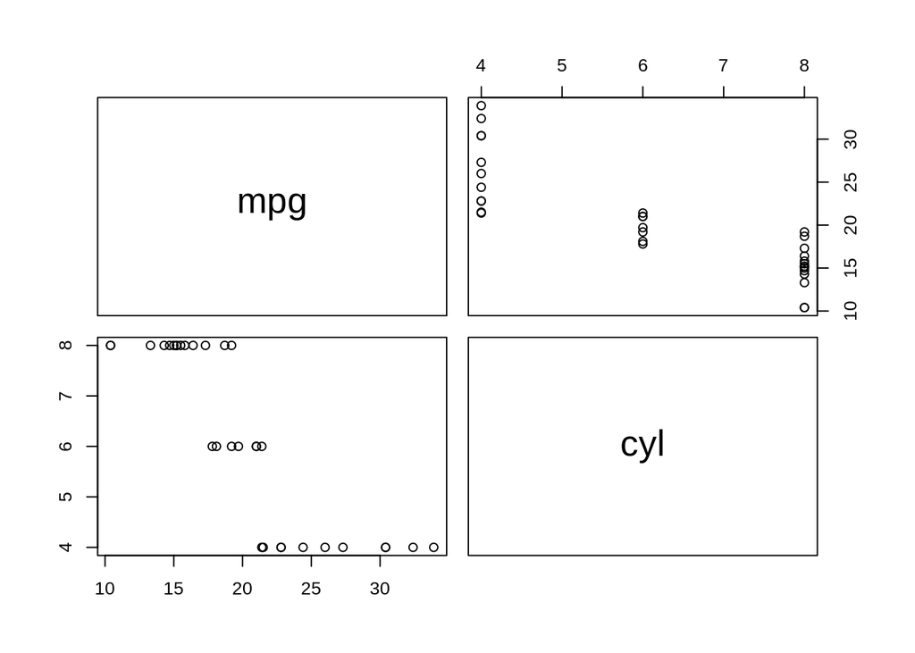

```r
pairs(mtcars[,1:2]) # pairs plot can be useful to see relationships
```

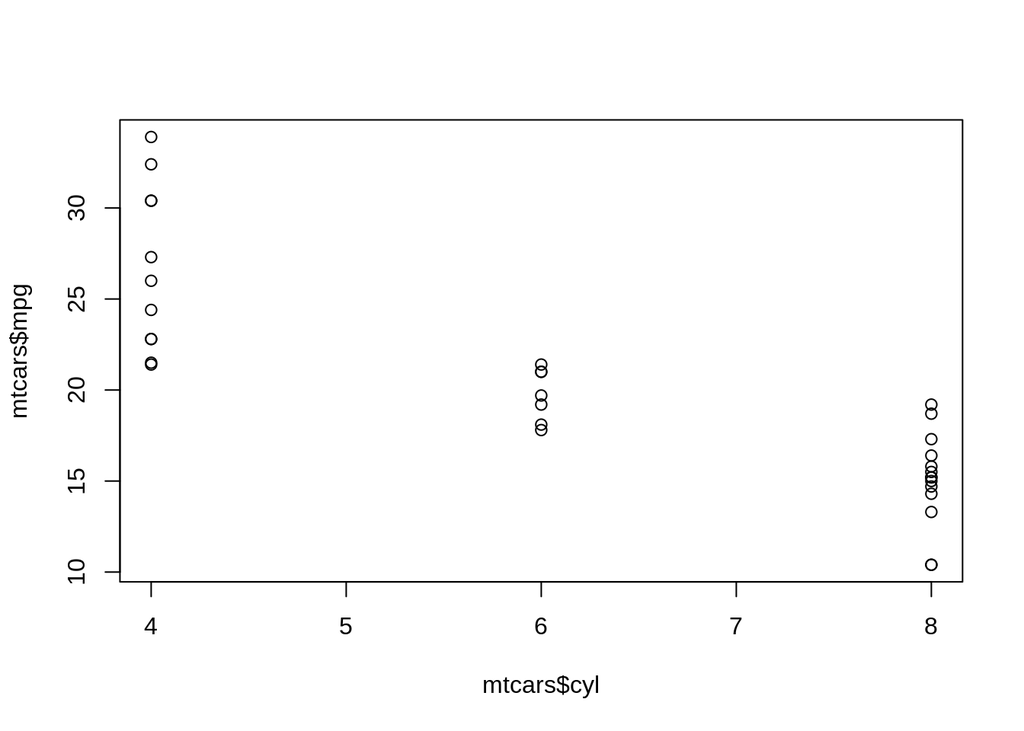

```r
plot(mtcars$cyl,mtcars$mpg) # scatterplot
```

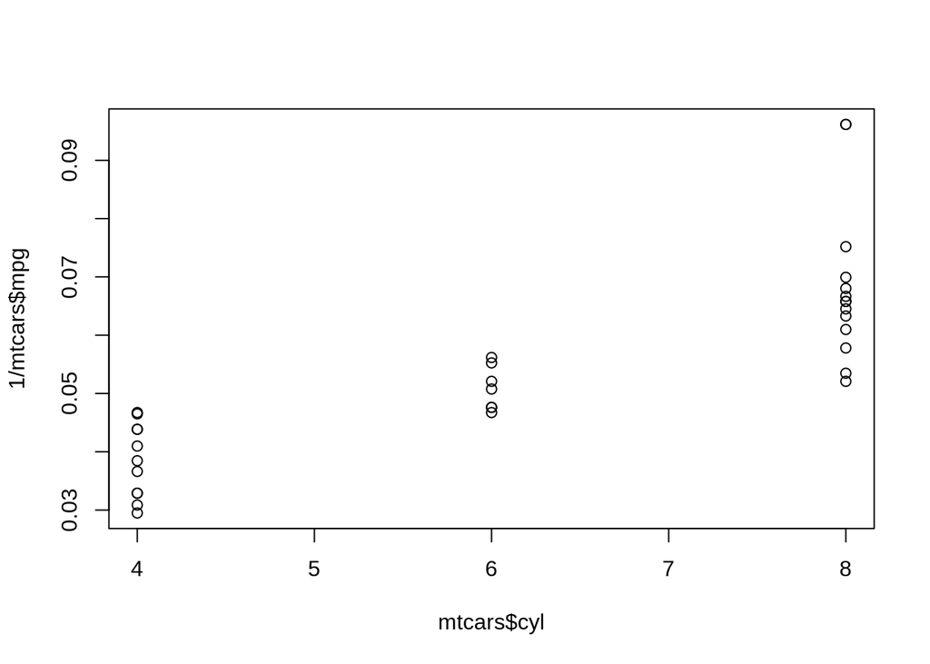

```r
plot(mtcars$cyl,1/mtcars$mpg) # 1/mpg gives the fuel economy
```

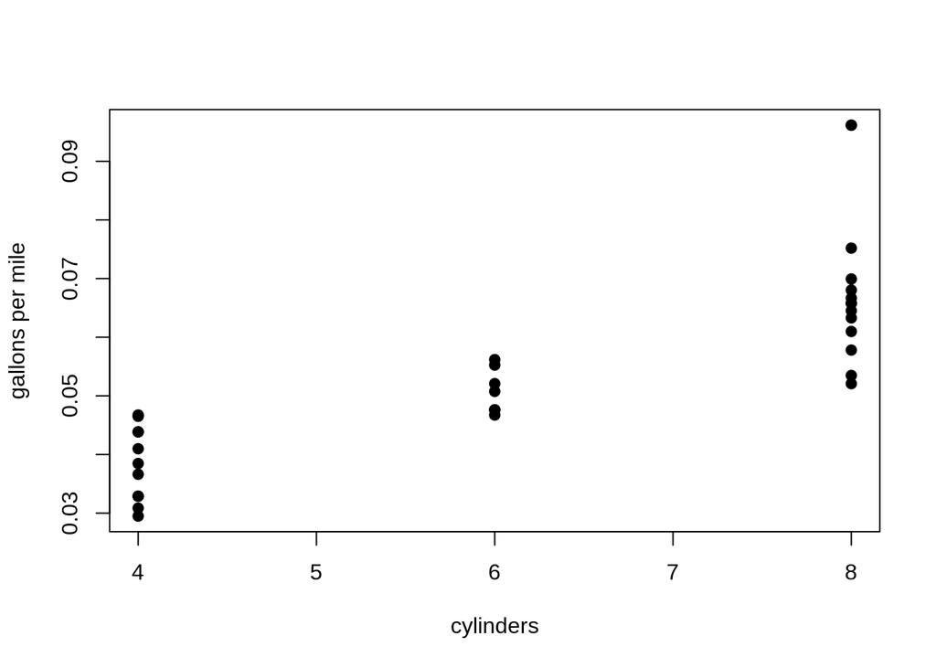

```r
plot(mtcars$cyl,1/mtcars$mpg,xlab="cylinders",ylab="gallons per mile",pch=19)
```

In any chart it is really important to give meaningful x and y labels.

```r
mylm<-lm(1/mpg ~ cyl, data=mtcars) # calculate the linear model
str(mylm) # the output is a big list object
```

```
## List of 12
##  $ coefficients : Named num [1:2] 0.00792 0.00748
##   ..- attr(*, "names")= chr [1:2] "(Intercept)" "cyl"
##  $ residuals    : Named num [1:32] -0.0052 -0.0052 0.006 -0.0061 -0.0143 ...
##   ..- attr(*, "names")= chr [1:32] "Mazda RX4" "Mazda RX4 Wag" "Datsun 710" "Hornet 4 Drive" ...
##  $ effects      : Named num [1:32] -0.30676 0.07441 0.00773 -0.00524 -0.01434 ...
##   ..- attr(*, "names")= chr [1:32] "(Intercept)" "cyl" "" "" ...
##  $ rank         : int 2
##  $ fitted.values: Named num [1:32] 0.0528 0.0528 0.0379 0.0528 0.0678 ...
##   ..- attr(*, "names")= chr [1:32] "Mazda RX4" "Mazda RX4 Wag" "Datsun 710" "Hornet 4 Drive" ...
##  $ assign       : int [1:2] 0 1
##  $ qr           :List of 5
##   ..$ qr   : num [1:32, 1:2] -5.657 0.177 0.177 0.177 0.177 ...
##   .. ..- attr(*, "dimnames")=List of 2
##   .. .. ..$ : chr [1:32] "Mazda RX4" "Mazda RX4 Wag" "Datsun 710" "Hornet 4 Drive" ...
##   .. .. ..$ : chr [1:2] "(Intercept)" "cyl"
##   .. ..- attr(*, "assign")= int [1:2] 0 1
##   ..$ qraux: num [1:2] 1.18 1.02
##   ..$ pivot: int [1:2] 1 2
##   ..$ tol  : num 1e-07
##   ..$ rank : int 2
##   ..- attr(*, "class")= chr "qr"
##  $ df.residual  : int 30
##  $ xlevels      : Named list()
##  $ call         : language lm(formula = 1/mpg ~ cyl, data = mtcars)
##  $ terms        :Classes 'terms', 'formula'  language 1/mpg ~ cyl
##   .. ..- attr(*, "variables")= language list(1/mpg, cyl)
##   .. ..- attr(*, "factors")= int [1:2, 1] 0 1
##   .. .. ..- attr(*, "dimnames")=List of 2
##   .. .. .. ..$ : chr [1:2] "1/mpg" "cyl"
##   .. .. .. ..$ : chr "cyl"
##   .. ..- attr(*, "term.labels")= chr "cyl"
##   .. ..- attr(*, "order")= int 1
##   .. ..- attr(*, "intercept")= int 1
##   .. ..- attr(*, "response")= int 1
##   .. ..- attr(*, ".Environment")=<environment: R_GlobalEnv>
##   .. ..- attr(*, "predvars")= language list(1/mpg, cyl)
##   .. ..- attr(*, "dataClasses")= Named chr [1:2] "numeric" "numeric"
##   .. .. ..- attr(*, "names")= chr [1:2] "1/mpg" "cyl"
##  $ model        :'data.frame':   32 obs. of  2 variables:
##   ..$ 1/mpg: num [1:32] 0.0476 0.0476 0.0439 0.0467 0.0535 ...
##   ..$ cyl  : num [1:32] 6 6 4 6 8 6 8 4 4 6 ...
##   ..- attr(*, "terms")=Classes 'terms', 'formula'  language 1/mpg ~ cyl
##   .. .. ..- attr(*, "variables")= language list(1/mpg, cyl)
##   .. .. ..- attr(*, "factors")= int [1:2, 1] 0 1
##   .. .. .. ..- attr(*, "dimnames")=List of 2
##   .. .. .. .. ..$ : chr [1:2] "1/mpg" "cyl"
##   .. .. .. .. ..$ : chr "cyl"
##   .. .. ..- attr(*, "term.labels")= chr "cyl"
##   .. .. ..- attr(*, "order")= int 1
##   .. .. ..- attr(*, "intercept")= int 1
##   .. .. ..- attr(*, "response")= int 1
##   .. .. ..- attr(*, ".Environment")=<environment: R_GlobalEnv>
##   .. .. ..- attr(*, "predvars")= language list(1/mpg, cyl)
##   .. .. ..- attr(*, "dataClasses")= Named chr [1:2] "numeric" "numeric"
##   .. .. .. ..- attr(*, "names")= chr [1:2] "1/mpg" "cyl"
##  - attr(*, "class")= chr "lm"
```

```r
summary(mylm) # summary helps to make sense of it
```

```
##
## Call:
## lm(formula = 1/mpg ~ cyl, data = mtcars)
##
## Residuals:
##       Min        1Q    Median        3Q       Max
## -0.015708 -0.005205 -0.001614  0.003184  0.028362
##
## Coefficients:
##              Estimate Std. Error t value Pr(>|t|)
## (Intercept) 0.0079219  0.0062773   1.262    0.217
## cyl         0.0074837  0.0009759   7.669 1.49e-08 ***
## ---
## Signif. codes:  0 '***' 0.001 '**' 0.01 '*' 0.05 '.' 0.1 ' ' 1
##
## Residual standard error: 0.009704 on 30 degrees of freedom
## Multiple R-squared:  0.6622, Adjusted R-squared:  0.6509
## F-statistic: 58.81 on 1 and 30 DF,  p-value: 1.488e-08
```

```r
summary(mylm)$r.squared # we can extract values with summary
```

```
## [1] 0.6621879
```

```r
signif(summary(mylm)$r.squared,3)  # signif helps to limit the significant figures for presentation
```

```
## [1] 0.662
```

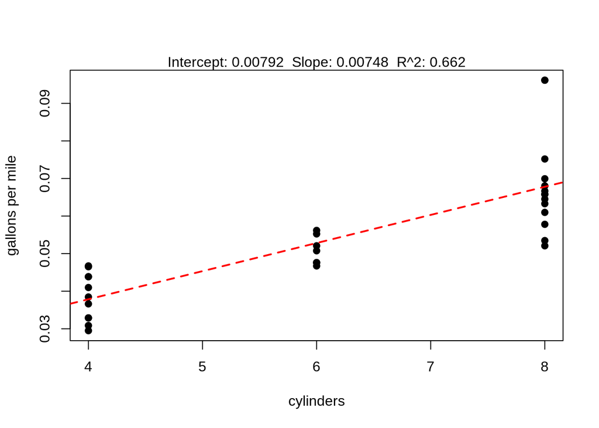

```r
plot(mtcars$cyl, 1/mtcars$mpg, xlab="cylinders",
     ylab="gallons per mile", pch=19)
abline( mylm , lty=2,lwd=2,col="red") # make trend line
# now we can extract some other values from the lm object to make a nice plot
INT=as.numeric(signif(mylm$coefficients[1],3))
SLOPE=as.numeric(signif(mylm$coefficients[2],3))
MYR2=signif(summary(mylm)$r.squared,3)
MYTEXT=paste("Intercept:",INT, " Slope:",SLOPE, " R^2:",MYR2)
mtext(MYTEXT)
```

### Reading data from a file

Reading in data from a file improperly is a major source of errors. For example if R doesn’t recognise column headers, then it can lead to the data being recognised as strings instead of numerical values. In the worst cases, the strings are represented as factors; then when maths operations are done, the user gets results which are totally wrong. Let’s have a look at the following typical example.

```r
# you will need to download the file first
download.file(url = "https://raw.githubusercontent.com/markziemann/SLE712_files/master/bioinfo_asst3_part1_files/mydata.tsv", destfile = "mydata.tsv")
# read.table a the command to read a table of data
head(read.table("mydata.tsv"))
```

```
##          V1         V2         V3         V4
## 1    GeneID ERR1720604 ERR1720605 ERR1720606
## 2   YDL248W       1107       1025        984
## 3 YDL247W-A          7         10         10
## 4   YDL247W          8          3          1
## 5   YDL246C          6          9          7
## 6   YDL245C          0          3          0
```

```r
x<-read.table("mydata.tsv") # typical way to import data, but be careful about how its imported
typeof(x)
```

```
## [1] "list"
```

```r
str(x) # check the data. Is it saved as numeric??
```

```
## 'data.frame':    101 obs. of  4 variables:
##  $ V1: Factor w/ 101 levels "GeneID","tG(GCC)D1",..: 1 101 100 99 98 97 96 95 94 93 ...
##  $ V2: Factor w/ 90 levels "0","1","101",..: 90 8 76 82 70 1 77 25 62 15 ...
##  $ V3: Factor w/ 89 levels "0","1","10","1003",..: 89 5 3 46 84 46 80 30 53 23 ...
##  $ V4: Factor w/ 89 levels "0","1","10","101",..: 89 88 3 2 74 1 11 26 57 14 ...
```

```r
x <- read.table("mydata.tsv",header=TRUE ) # set header=TRUE if you have headers on your data
str(x)
```

```
## 'data.frame':    100 obs. of  4 variables:
##  $ GeneID    : Factor w/ 100 levels "tG(GCC)D1","YDL156W",..: 100 99 98 97 96 95 94 93 92 90 ...
##  $ ERR1720604: int  1107 7 8 6 0 71 171 5 137 1 ...
##  $ ERR1720605: int  1025 10 3 9 3 85 190 4 159 0 ...
##  $ ERR1720606: int  984 10 1 7 0 127 185 5 132 0 ...
```

```r
x <- read.table("mydata.tsv", header=TRUE, row.names=1) # set row.names=1 if the 1st col is the row name
head(x)
```

```
##           ERR1720604 ERR1720605 ERR1720606
## YDL248W         1107       1025        984
## YDL247W-A          7         10         10
## YDL247W            8          3          1
## YDL246C            6          9          7
## YDL245C            0          3          0
## YDL244W           71         85        127
```

```r
str(x)  # check that it's numeric
```

```
## 'data.frame':    100 obs. of  3 variables:
##  $ ERR1720604: int  1107 7 8 6 0 71 171 5 137 1 ...
##  $ ERR1720605: int  1025 10 3 9 3 85 190 4 159 0 ...
##  $ ERR1720606: int  984 10 1 7 0 127 185 5 132 0 ...
```

```r
# here is another correct way to import especially if you have gene names (strings)
x<-read.table("mydata.tsv",header=T,
  stringsAsFactors=FALSE,sep="\t")
str(x)
```

```
## 'data.frame':    100 obs. of  4 variables:
##  $ GeneID    : chr  "YDL248W" "YDL247W-A" "YDL247W" "YDL246C" ...
##  $ ERR1720604: int  1107 7 8 6 0 71 171 5 137 1 ...
##  $ ERR1720605: int  1025 10 3 9 3 85 190 4 159 0 ...
##  $ ERR1720606: int  984 10 1 7 0 127 185 5 132 0 ...
```

```r
# another correct way to import the data
x<-read.csv("mydata.tsv",sep="\t", stringsAsFactors=FALSE)
str(x)
```

```
## 'data.frame':    100 obs. of  4 variables:
##  $ GeneID    : chr  "YDL248W" "YDL247W-A" "YDL247W" "YDL246C" ...
##  $ ERR1720604: int  1107 7 8 6 0 71 171 5 137 1 ...
##  $ ERR1720605: int  1025 10 3 9 3 85 190 4 159 0 ...
##  $ ERR1720606: int  984 10 1 7 0 127 185 5 132 0 ...
```

### Saving R sessions

This can help you save time especially if you have been running a large data analysis, you can save the results for future reference so you don’t need to execute it again.

```r
# save a session
save.image("mydata.RData")
# now in the menu bar select “quit session”
# then start new session
# see if x is saved
x
```

```
##        GeneID ERR1720604 ERR1720605 ERR1720606
## 1     YDL248W       1107       1025        984
## 2   YDL247W-A          7         10         10
## 3     YDL247W          8          3          1
## 4     YDL246C          6          9          7
## 5     YDL245C          0          3          0
## 6     YDL244W         71         85        127
## 7     YDL243C        171        190        185
## 8     YDL242W          5          4          5
## 9     YDL241W        137        159        132
## 10  YDL240C-A          1          0          0
## 11    YDL240W        333        378        364
## 12    YDL239C        149        169        198
## 13    YDL238C        105        118        105
## 14    YDL237W        843        710        720
```

[output cut: 86 more lines]

```r
# load session
load("mydata.RData")
#    see if x is saved x
```